# Word Prediction System of Capstone Project

C. Ou  
2016-04-18

### About Word Prediction System

. Main purpose is to build a shiny application that is able to predict the next word.

. More detailed about the App, please see: https://fooway.shinyapps.io/DataSci_Capstone_Project

. The whole codes of this application can be found in this GitHub repo: https://github.com/Fooway/DataSci_Capstone_Project.git

. Learn more about the Coursera Data Science Specialization: https://www.coursera.org/specialization/jhudatascience/1

### Usage of Word Prediction System

Main Interface; More See **User Guide** and **About**.

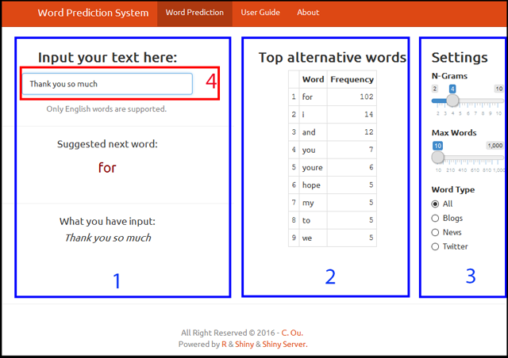

Simply input you words, and display the next words.

### Database Design of SQLite

. Create a table called *NGrams* including five columns (*type*, *word*, *next*, *frequency* and *ngram*)

. Store frequency dictionaries (from 2-Grams to 10-Grams) into **SQLite** database

. Optimize the SQLite database to meet the requirements of both efficiency and accuracy

. Compress **Full Version** database (**4.89GB**) into **Lite Version** database (**86.2MB**) which meets free ShinyApps.io server requirements

### Prediction of Stupid Backoff Method

. Aggregate term frequency matrices from 2-Grams to 10-Grams

. Transfer them into frequency dictionaries

. Predict Word of N-Grams and Stupid Backoff method was proposed by Brants et al (2007)

. Search the word frequency dictionary database from higher gram to lower gram

. Stop if the matched words; Otherwise, back off to lower gram